# Principal Component Analysis and Multidimensional Scaling

Aleksandra Lubicka

# DATA

In the data set, each observation is characterized by 4 quantitative variables describing the features of the apartments sold: **floor_area_sqm**, **resale_price**, **age**, **room_numb**, **town**.

```r
kable(dane[1:10,], align = "cc", caption = "Table 1.1 The first 10 rows of the database.")
```

Table 1.1 The first 10 rows of the database.

| month | town | flat_type | block | street_name | storey_range | floor_area_sqm | flat_model | construction_date | remaining_lease | resale_price | age | room_numb |
| --- | --- | --- | --- | --- | --- | --- | --- | --- | --- | --- | --- | --- |
| 2017-01 | ANG MO KIO | 3 ROOM | 602 | ANG MO KIO AVE 5 | 01 TO 03 | 67 | New Generation | 1980 | 62 years 05 months | 262000 | 40 | 3 |
| 2017-01 | ANG MO KIO | 3 ROOM | 218 | ANG MO KIO AVE 1 | 04 TO 06 | 67 | New Generation | 1976 | 58 years 04 months | 285000 | 44 | 3 |
| 2017-01 | ANG MO KIO | 3 ROOM | 235 | ANG MO KIO AVE 3 | 04 TO 06 | 67 | New Generation | 1977 | 59 years 08 months | 295000 | 43 | 3 |
| 2017-01 | ANG MO KIO | 3 ROOM | 624 | ANG MO KIO AVE 4 | 04 TO 06 | 68 | New Generation | 1980 | 62 years 08 months | 301000 | 40 | 3 |
| 2017-01 | ANG MO KIO | 3 ROOM | 432 | ANG MO KIO AVE 10 | 10 TO 12 | 67 | New Generation | 1979 | 61 years | 325000 | 41 | 3 |
| 2017-01 | ANG MO KIO | 3 ROOM | 256 | ANG MO KIO AVE 4 | 10 TO 12 | 73 | New Generation | 1977 | 59 years 06 months | 335000 | 43 | 3 |
| 2017-01 | ANG MO KIO | 3 ROOM | 509 | ANG MO KIO AVE 8 | 01 TO 03 | 81 | New Generation | 1980 | 62 years 05 months | 390000 | 40 | 3 |
| 2017-01 | ANG MO KIO | 4 ROOM | 472 | ANG MO KIO AVE 10 | 10 TO 12 | 92 | New Generation | 1979 | 61 years 06 months | 400000 | 41 | 4 |
| 2017-01 | ANG MO KIO | 4 ROOM | 254 | ANG MO KIO AVE 4 | 04 TO 06 | 97 | New Generation | 1977 | 59 years 06 months | 430000 | 43 | 4 |
| 2017-01 | ANG MO KIO | 4 ROOM | 304 | ANG MO KIO AVE 1 | 10 TO 12 | 97 | New Generation | 1977 | 59 years 04 months | 518000 | 43 | 4 |

# PCA

My first analysis is Principal Components Analysis, which aims to reduce the number of variables by finding components that are a linear combination of these variables.Indication of variables that have a large impact on the appearance of individual principal components allows for the indication of a group representative. Other components are mutually uncorrelated and they have to maximize the variability that was not explained by the previous component.The parameters which possess the highest degree of variation will be the most optimal predictor of house prices.

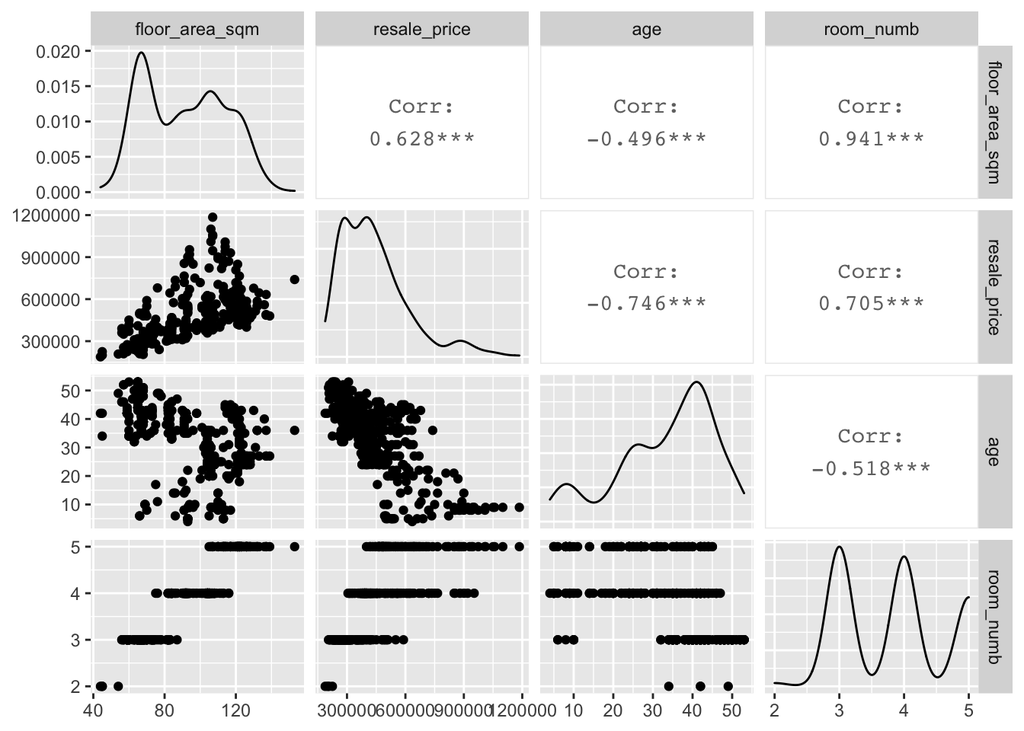

Figure 1.1 The correlation matrix.

```r
dane_PCA = dane %>% filter(town== c("CENTRAL AREA", "TOA PAYOH", "PASIR RIS", "BEDOK"))
dane_PCA = dane_PCA %>% select(floor_area_sqm, resale_price, age, room_numb, town)
ggpairs(data = dane_PCA, columns = 1:4)
```

If the correlation did not occur, it would not be possible to determine the principal components because each component would be as good as the other.

The data contains mixed units, so we need to mean-center the data and divide it by standard deviation and then apply a correlation matrix.

```r
normalize <- function(x)
{
  return((x - mean(x))/sd(x))
}
dane_PCA[,1:4] <- dane_PCA[,1:4] %>% apply(2, normalize) %>% as.data.frame()

# correlation matrix
cor <- cor(dane_PCA[,1:4])
eigenvalues <- eigen(cor)

rownames(eigenvalues$vectors) <- c("floor_area_sqm", "resale_price", "age", "room_numb")
colnames(eigenvalues$vectors) <- c("PC1", "PC2", "PC3", "PC4")
eigenvalues2=as.data.frame(eigenvalues$vectors)
```

Matrix of eigenvectors:

```r
kable(eigenvalues2, align = "cc", caption = "Table 1.2 The matrix of eigenvectors.")
```

Table 1.2 The matrix of eigenvectors.

|  | PC1 | PC2 | PC3 | PC4 |
| --- | --- | --- | --- | --- |
| floor_area_sqm | 0.5123898 | -0.4921707 | 0.2628761 | 0.6527793 |
| resale_price | 0.5074730 | 0.3467126 | -0.7696300 | 0.1730066 |
| age | -0.4474903 | -0.6748076 | -0.5818025 | 0.0767654 |
| room_numb | 0.5288480 | -0.4268407 | -0.0084705 | -0.7335223 |

```r
pc1.var <- 100*round(eigenvalues$values[1]/sum(eigenvalues$values), digits = 3)
pc2.var <- 100*round(eigenvalues$values[2]/sum(eigenvalues$values), digits = 3)
pc3.var <- 100*round(eigenvalues$values[3]/sum(eigenvalues$values), digits = 3)
pc4.var <- 100*round(eigenvalues$values[4]/sum(eigenvalues$values), digits = 3)

pc <- data.frame(PC = c("PC1", "PC2", "PC3", "PC4"), Percentage = c(pc1.var, pc2.var, pc3.var, pc4.var))
pc= as.data.frame(pc)
```

Main component variance:

```r
kable(pc, align = "cc", caption = "Table 1.3 The variance of main component.")
```

Table 1.3 The variance of main component.

| PC | Percentage |
| --- | --- |
| PC1 | 75.7 |
| PC2 | 17.4 |
| PC3 | 5.7 |
| PC4 | 1.3 |

We can see that the major component describes 76% of the variance. The first two components describe 93% of the variance.

```r
PCA <- prcomp(dane_PCA[,1:4], center = TRUE, scale. = TRUE)
pca_summary <- summary(PCA)$importance %>% as.data.frame()
kable(pca_summary, align = "cc", caption = "Table 1.3 Summary.")
```

Table 1.3 Summary.

|  | PC1 | PC2 | PC3 | PC4 |
| --- | --- | --- | --- | --- |
| Standard deviation | 1.739611 | 0.8332554 | 0.4786093 | 0.2244371 |
| Proportion of Variance | 0.756560 | 0.1735800 | 0.0572700 | 0.0125900 |
| Cumulative Proportion | 0.756560 | 0.9301400 | 0.9874100 | 1.0000000 |

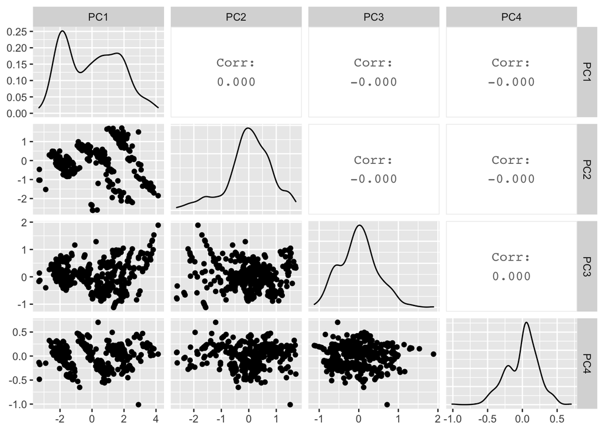

Figure 1.2 The correlation matrix.

```r
ggpairs(data = as.data.frame(PCA$x) , columns = 1:4)
```

Components are orthogonal vectors. The analysis will reduce the set of correlated variables to components that are not correlated with each other with the least possible loss of information.

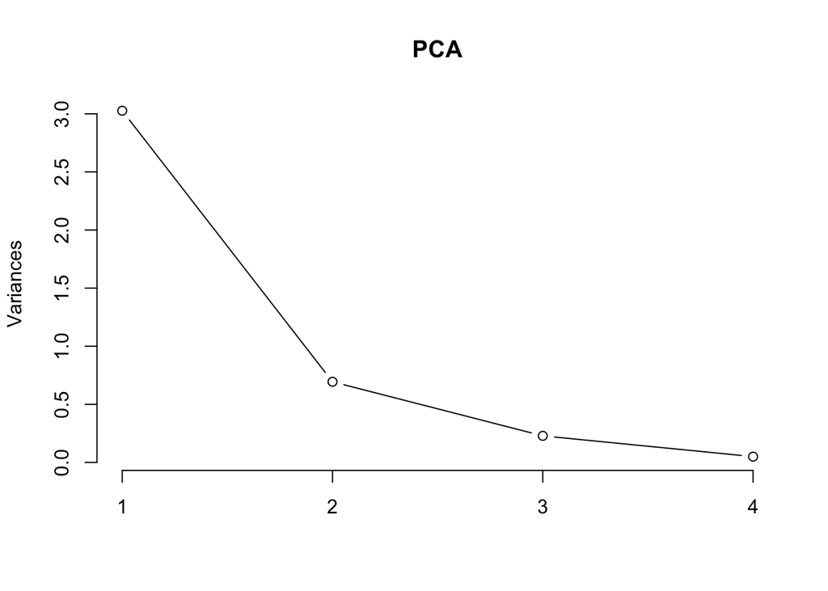

Figure 1.3 Scree Plot - Morphometric Data.

```r
screeplot(PCA, type = "line")
```

The scree plot can also be used to select the main components. The factors are placed on the horizontal axis, and their eigenvalues are placed on the vertical axis. We are looking for the break points at which the curve’s refraction angle changes.

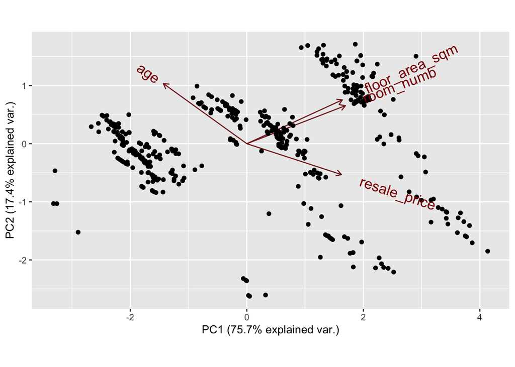

Figure 1.4 Principal component analysis (PCA).

```r
ggbiplot(PCA, obs.scale=1, var.scale=1, varname.size=5)
```

Arrows with the names of the variables show in which directions and how much they affect the individual main components.

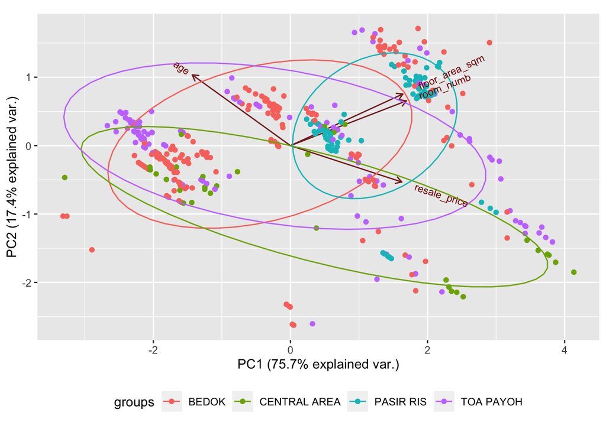

Figure 1.5 Principal component analysis (PCA) - groups.

```r
pca.species <- dane_PCA[,5]
ggbiplot(PCA, obs.scale=1, var.scale=1, ellipse=TRUE, groups = pca.species)+theme(legend.position="bottom")
```

The analysis made it possible to reduce the number of variables to two without a significant loss of the information contained.Principal component analysis enables the description of consumer behavior in the market. It allows you to determine the position of the product in relation to competitive products.